# QuantTwit

[figure not shown]

[figure not shown]

[figure not shown]

[figure not shown]

[figure not shown]

[figure not shown]

# Prospects List

### About Prospects List

Here are the top prospects for this report, taken from the 3000 most recent followers of “parenting” Twitter account. They have been filter to assure they are a new account made within the last 150 days, have a friend to follower ratio suggesting they are not a bot or celebrity (regular people probably buy more than celebrities), and also that they are active (favorites per day). We further assured this group is a match by comparing their interests to your most recent 3000 followers interests.

### Top Prospects

| screenName | days | friendfollowerRatio | favoritesCount_pDay | followersCount | friendsCount | favoritesCount |
| --- | --- | --- | --- | --- | --- | --- |
| thestinkerbell_ | 8 | 0.5702479 | 37.3750000 | 121 | 69 | 299 |
| GeeGee39531976 | 22 | 2.0000000 | 28.3636364 | 21 | 42 | 624 |
| merrittalbliss | 19 | 1.6685714 | 21.0526316 | 350 | 584 | 400 |
| mymommyposts | 105 | 1.4086486 | 17.8476190 | 925 | 1303 | 1874 |
| MilkiesNcookies | 45 | 1.1958506 | 13.1777778 | 1205 | 1441 | 593 |
| MenaEnesto | 28 | 2.7692308 | 11.3571429 | 65 | 180 | 318 |
| the_edu_table | 28 | 1.3949367 | 10.5357143 | 395 | 551 | 295 |
| ParentingFusion | 8 | 2.7500000 | 10.5000000 | 4 | 11 | 84 |
| PedsForPres | 30 | 2.7492711 | 6.4000000 | 343 | 943 | 192 |
| LauraBoycourt | 144 | 1.5811966 | 6.1666667 | 117 | 185 | 888 |
| DadsGlobal | 74 | 2.6000000 | 6.1486486 | 150 | 390 | 455 |
| FakharA00973311 | 8 | 2.2137405 | 6.0000000 | 262 | 580 | 48 |
| menotyo70696917 | 44 | 2.8400000 | 5.1818182 | 450 | 1278 | 228 |
| Nekeya11 | 44 | 2.0606061 | 3.5227273 | 33 | 68 | 155 |
| EmbracePotholes | 73 | 2.1376147 | 3.2876712 | 218 | 466 | 240 |
| amanda58749996 | 21 | 2.5290323 | 2.9523810 | 155 | 392 | 62 |
| kidsfinancial3 | 15 | 2.1263158 | 2.6000000 | 95 | 202 | 39 |
| yaztaz53 | 48 | 2.9649123 | 2.2708333 | 114 | 338 | 109 |
| fineass_teiia | 3 | 1.7500000 | 1.6666667 | 8 | 14 | 5 |
| Jasminelovegod | 49 | 2.6000000 | 1.5306122 | 10 | 26 | 75 |
| BlanquelVictor | 48 | 2.3666667 | 1.2500000 | 30 | 71 | 60 |
| JoySasso | 82 | 2.6666667 | 0.8658537 | 9 | 24 | 71 |
| beradicallife | 7 | 2.1818182 | 0.8571429 | 11 | 24 | 6 |
| LiniVatuloka | 37 | 2.9000000 | 0.8378378 | 10 | 29 | 31 |
| allurebaby11 | 24 | 1.7678571 | 0.3333333 | 56 | 99 | 8 |
| MaywoodMustang | 22 | 1.8181818 | 0.3181818 | 11 | 20 | 7 |
| kalkhofk1 | 78 | 1.9032258 | 0.2948718 | 31 | 59 | 23 |
| PoetPostpartum | 86 | 1.9354839 | 0.1860465 | 31 | 60 | 16 |
| LearnWithMochi | 108 | 1.3965517 | 0.1666667 | 58 | 81 | 18 |
| AuthorSelley | 72 | 2.8020833 | 0.1250000 | 96 | 269 | 9 |
| cdp_villanova | 20 | 2.6800000 | 0.1000000 | 25 | 67 | 2 |
| SarahPa49092241 | 44 | 2.0000000 | 0.0681818 | 18 | 36 | 3 |
| MomCoach_KT | 77 | 1.1666667 | 0.0519481 | 12 | 14 | 4 |
| elmizri | 10 | 2.0000000 | 0.0000000 | 1 | 2 | 0 |
| thoughtsymphony | 10 | 1.0000000 | 0.0000000 | 2 | 2 | 0 |
| EarlyDiscoveri1 | 10 | 2.5000000 | 0.0000000 | 2 | 5 | 0 |
| FelyMommy | 11 | 2.3333333 | 0.0000000 | 3 | 7 | 0 |
| ArnesonDenise | 16 | 2.0000000 | 0.0000000 | 1 | 2 | 0 |
| EzekielaFergus1 | 19 | 0.9047619 | 0.0000000 | 42 | 38 | 0 |
| JEngelhardt8 | 32 | 1.0000000 | 0.0000000 | 1 | 1 | 0 |
| SArimbrister | 33 | 0.9069767 | 0.0000000 | 43 | 39 | 0 |
| AscSurrogacy | 36 | 2.3333333 | 0.0000000 | 3 | 7 | 0 |
| samanth95410040 | 44 | 2.6666667 | 0.0000000 | 3 | 8 | 0 |
| melisa_oka | 45 | 2.8888889 | 0.0000000 | 9 | 26 | 0 |
| CGarden901 | 46 | 2.6666667 | 0.0000000 | 3 | 8 | 0 |

# Prospect Insights

### About Prospect Insights

This section serves two purposes. The first purpose is to provide additional information about the interests of your prospective audience. The second purpose is to act as quality control. Seeing similar key words and “bi-grams” (two words commonly seen in the same bio) assure the supplied pool of prospects is a close fit with your existing audience.

### Current Audience Key Bio Words

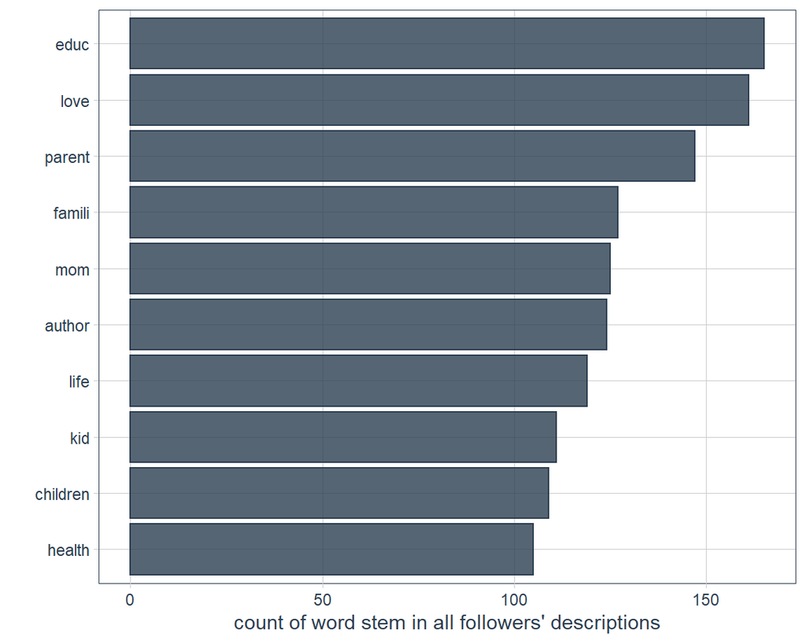

### Prospect Key Bio Words

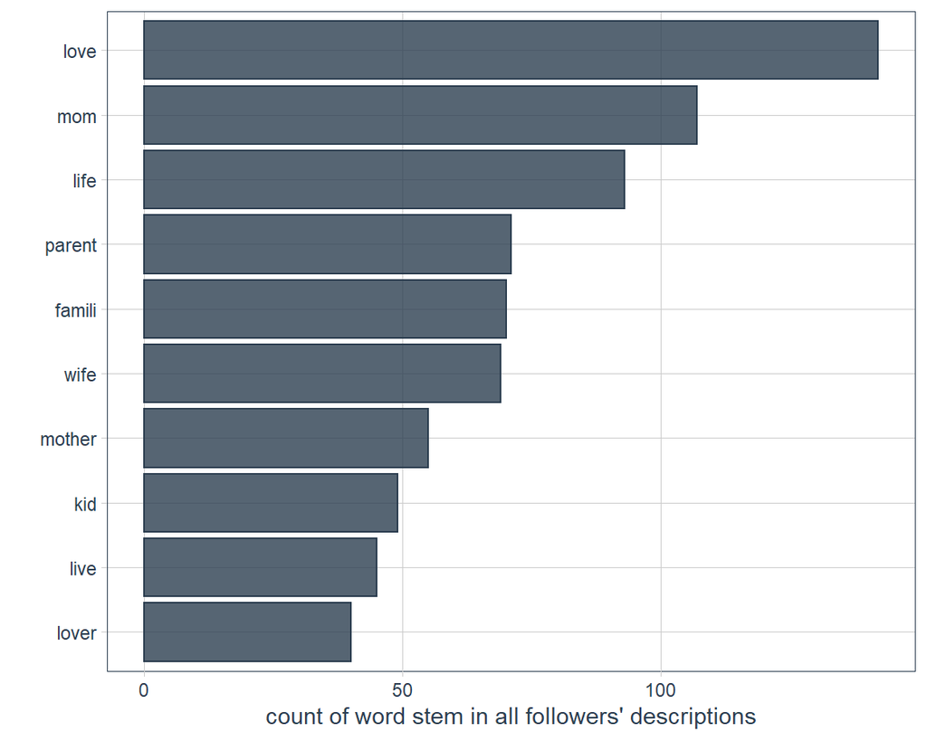

### Current Audience Top Bigrams

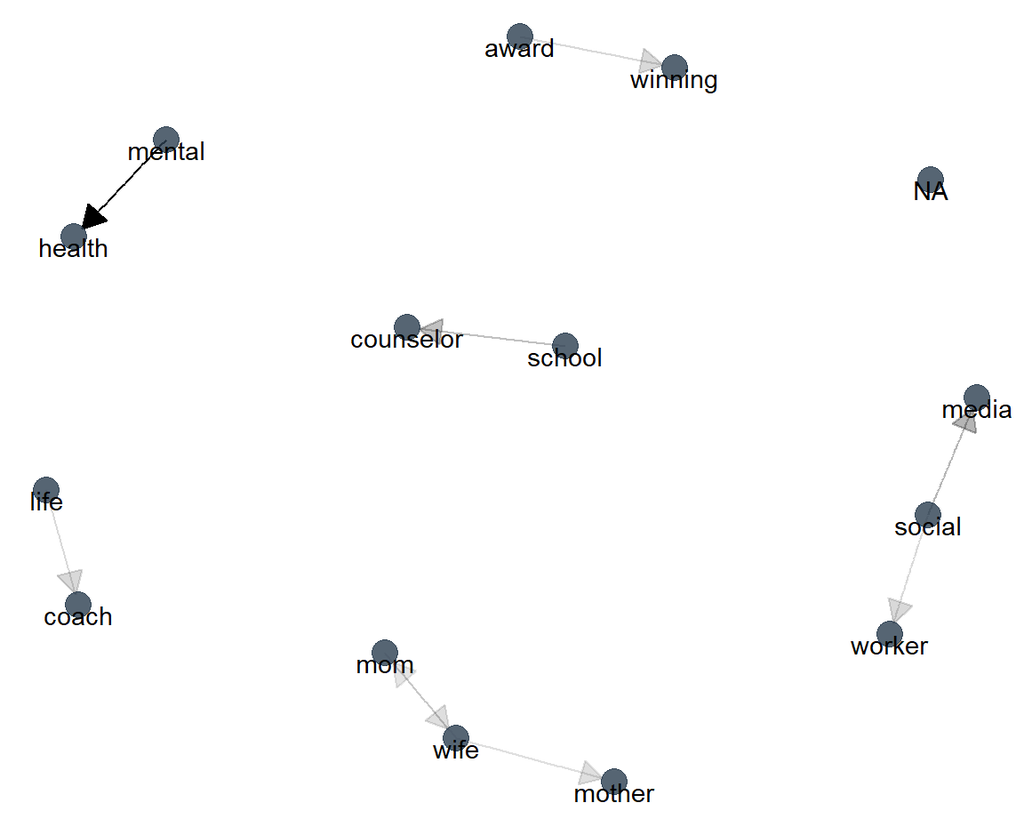

### Prospect Top Bigrams

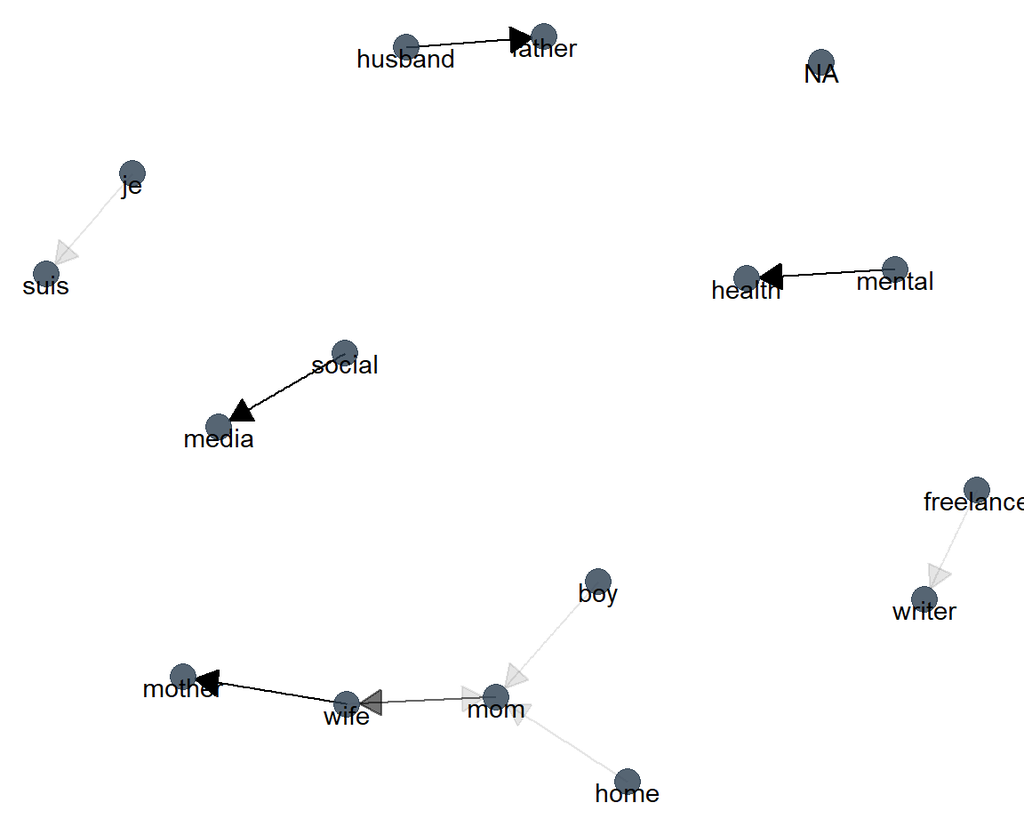

# EOI

### About EOI

Engagement Optimization Insights (EOI) uses a powerful yet understandable algorithm to create actionable insights aimed at improving user engagement. There are many variables contributing to the engagement level of a tweet, including the message of the content itself. You control the message, but our algorithm can make suggestions on how to structure that message to optimize engagement measured by favorites and retweets. Current factors we consider for predicting engagement are time, average words (counted), length of average word, and total length of message. Immediately below, we see your top performing tweets (measured by favorites). Further below we see an analysis of factors effecting performance.

| text | favoriteCount | retweetCount |
| --- | --- | --- |
| A little smile goes a long way. https://t.co/0j1ykvXVOd | 9 | 4 |
| Tough parenting moments? Breathe. Calm down. Here’s our 2 Minutes to Calm for Parents https://t.co/wX9YMc7tNg Your… https://t.co/Jp5WIMz7fm | 7 | 4 |
| You are just where you are supposed to be. Right now, in this moment. | 6 | 4 |
| Never stop learning. | 6 | 2 |
| Keep a smile in your heart to share with someone who really needs it! #kidlutions | 5 | 2 |
| Kids suffer when they struggle with making and keeping friends. We can help in a big way: https://t.co/bLPHwrTRTG https://t.co/b3M4dP4kKe | 5 | 2 |
| YES! We always incorporate elements of movement in therapy, as well! So does our pal and colleague @DrLynneKenney https://t.co/JueaosKlZk | 5 | 2 |
| When you are angry, how do you manage things? What are you #teaching your #children? | 5 | 2 |
| Have you listened to your children today? REALLY listened? #kidlutions | 5 | 2 |
| A little smile goes a long way. https://t.co/vDW6rFhN60 | 4 | 4 |
| Kindness: You’ll never regret it. Teach kids how to be kind. Show them! https://t.co/7PVS6NP9VP https://t.co/4np3Z89kXa | 4 | 4 |
| Giving compliments is a #socialskill that often needs to be taught to #kids https://t.co/MyoKc2tqaa https://t.co/7imjMNvP2w | 4 | 2 |
| When you are angry, how do you manage things? What are you #teaching your #children? | 4 | 2 |
| Just breathe. https://t.co/d3vuOhmUA3 | 3 | 2 |
| Whatever it is that you are after…go after it with a vengeance. When brick walls appear, go around them, dig under them…do what you must | 3 | 2 |
| Just breathe. https://t.co/A7ounKgQ8q | 3 | 3 |
| Does your child’s #anger or #worry feel like a tsunami? Here’s help! https://t.co/ywEeBgMRBn https://t.co/cjTzPthHOh | 3 | 2 |
| Whatever it is that you are after…go after it with a vengeance. When brick walls appear, go around them, dig under them…do what you must | 3 | 2 |
| Parenting is delightful. It’s also a challenge.We hear you and we know. #kidlutions | 3 | 2 |
| Kindness: You’ll never regret it. Teach kids how to be kind. Show them! https://t.co/7PVS6Nxyxf https://t.co/xgjLJqPw9M | 3 | 3 |
| Smile at someone you don’t know. See how much happier it makes you! #kidlutions | 2 | 2 |
| Activities and crafts that help teach kids about #empathy https://t.co/dM5f58AGHN https://t.co/GwT93AfyHj | 2 | 2 |
| Be a calm, relaxed and confident parent! https://t.co/rfk69TKtkU #kidlutions | 2 | 2 |
| Kindness: You’ll never regret it. Teach kids how to be kind. Show them! https://t.co/7PVS6NP9VP https://t.co/V44xB4ig34 | 2 | 2 |
| Whatever it is that you are after…go after it with a vengeance. When brick walls appear, go around them, dig under them…do what you must | 2 | 2 |
| Help kids grow in #empathy. Here’s a kit that gives you a great start! https://t.co/dM5f58AGHN https://t.co/6urd399W7t | 2 | 2 |
| Cuz it’s all about those feelings… Help your child survive and thrive with all sorts of #feelings https://t.co/ylpPTehhLH #emotional | 2 | 2 |
| Cool Down Strategies for Kids help kids #cope with #anger https://t.co/1SHrEjCzUL https://t.co/VwkQpzns8J | 2 | 2 |
| Parenting: We’re all in this together. https://t.co/rfk69TKtkU | 2 | 2 |
| Kids don’t need you to be a perfect parent. They need you do be fully human, so you can help them do the same. https://t.co/rfk69TKtkU | 2 | 2 |
| You are just where you are supposed to be. Right now, in this moment. | 2 | 2 |
| We are about as happy as we make our minds up to be. https://t.co/081y7unqZX | 2 | 2 |
| Playful Ways to Help Kids Cope with Divorce:Combo Set https://t.co/bv7xWm3U76 #divorce #parenting | 2 | 2 |
| See your child and yourself in a whole new way! #thejoyfulparent #parentinghelp https://t.co/SLjisRmpC4 | 2 | 2 |
| Kindness: You’ll never regret it. Teach kids how to be kind. Show them! https://t.co/7PVS6NP9VP https://t.co/rLX7oHSqyE | 2 | 2 |
| Help kids learn how to manage #feelings with this #apple themed resource https://t.co/Zmb6ZKxHYN https://t.co/goe9TlF5Zp | 2 | 3 |
| Optimism. Pass it on. https://t.co/pvu11TgiI1 | 2 | 2 |
| Activities and crafts that help teach kids about #empathy https://t.co/dM5f58AGHN https://t.co/EERInmpW2t | 2 | 2 |
| Tough parenting moments? Breathe. Calm down. Here’s our 2 Minutes to Calm for Parents https://t.co/wX9YMbPSoG Your… https://t.co/M8dt0D1MgB | 2 | 3 |
| Keep it positive. You are what you think! Kidlutions can help kids with this and so much more!… https://t.co/1qaNZO6GWb | 2 | 2 |
| Just breathe. https://t.co/Z6R7HVnlyk | 2 | 2 |
| Tough parenting moments? Breathe. Calm down. Here’s our 2 Minutes to Calm for Parents https://t.co/lEkJSVKiOa Your… https://t.co/zKVfmkAFZj | 2 | 2 |
| Punishment not working? Try #BLOOM. https://t.co/l0BG1I3yLY https://t.co/D5PzVu3jrj | 2 | 2 |
| Kids suffer when they struggle with making and keeping friends. We can help in a big way: https://t.co/bLPHwrTRTG https://t.co/BF7rI00x4U | 1 | 2 |
| Keep it positive. You are what you think! Kidlutions can help kids with this and so much more!… https://t.co/LJqImNTlgy | 1 | 2 |
| Go with the flow. It’s a lot less taxing. #kidlutions | 1 | 2 |
| Kids suffer when they struggle with making and keeping friends. We can help in a big way: https://t.co/bLPHwrTRTG https://t.co/PwPRvCwpXq | 1 | 3 |
| Just be. https://t.co/FVana1XuRP | 1 | 2 |
| Whenever possible…be kind. https://t.co/7PVS6NP9VP https://t.co/36RDNT6WMB | 1 | 2 |
| Help for kids when they are #sad https://t.co/90zY9UpibL https://t.co/tUUUUrLH6l | 1 | 2 |
| You are just where you are supposed to be. Right now, in this moment. | 1 | 2 |
| Challenging Children: The Upside. #parents #parenting https://t.co/52FquamY8Z | 1 | 2 |
| To be kind is everything. Teach your kids! https://t.co/7PVS6NP9VP | 1 | 2 |
| Resiliency. Kids get it when they learn how to manage BIG emotions https://t.co/rfk69TKtkU #feelings #emotions | 1 | 2 |
| S ~ M ~ I ~ L ~ E | 1 | 3 |
| Teach Kids #Kindness on a Daily Basis. This can help! https://t.co/3dlY3AMyDf https://t.co/x4AtYOW9ZF | 1 | 2 |
| Help kids grow in #empathy. Here’s a kit that gives you a great start! https://t.co/dM5f58AGHN https://t.co/g1zBcf4Rwu | 1 | 2 |
| Teach your kids that what they think matters. Kidlutions can help! https://t.co/kIoAsHoJO5 | 1 | 2 |
| To be kind is everything. Teach your kids! https://t.co/7PVS6NP9VP https://t.co/svDlbhZuGf | 1 | 2 |
| They copy everything you do and say. Make it awesome! Join us! #thejoyfulparent https://t.co/SLjisRmpC4 https://t.co/WDAD9nthbw | 1 | 2 |
| #MotherLoss is so difficult. Help #teen boys cope: https://t.co/70c4BTZXKG | 0 | 2 |
| Optimism. Pass it on. https://t.co/XE2HzznS0L | 0 | 2 |
| Embrace the moment! https://t.co/LYY84MbP91 | 0 | 2 |
| B ~ R ~ E ~ A ~ T ~ H ~ E ! #kidlutions | 0 | 2 |
| See how taking a bath can help with #anxiety https://t.co/6ZCCnXaKuK https://t.co/ICgn6A4uyN | 0 | 3 |

### About Factor Analysis

Here we can see the predictive value of the different variables and how they effect favorites. There are some linear effects, such as increasing http links correlating with LOWER engagement (measured by favorites) or a increase in the use of numbers (eg. 5 ways to calm down in 1 minute) correlating with HIGHER engagement. There are also mixed effects such as time of tweet (UTC Timezone) or Capital letters used per tweet.

### Mixed Effects

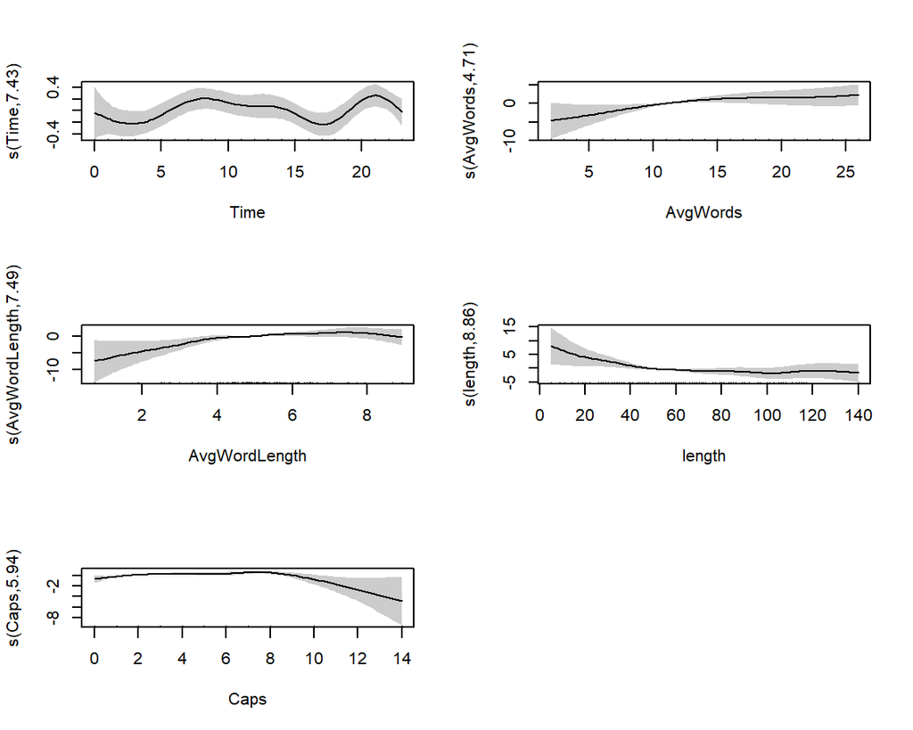

### Linear Effects

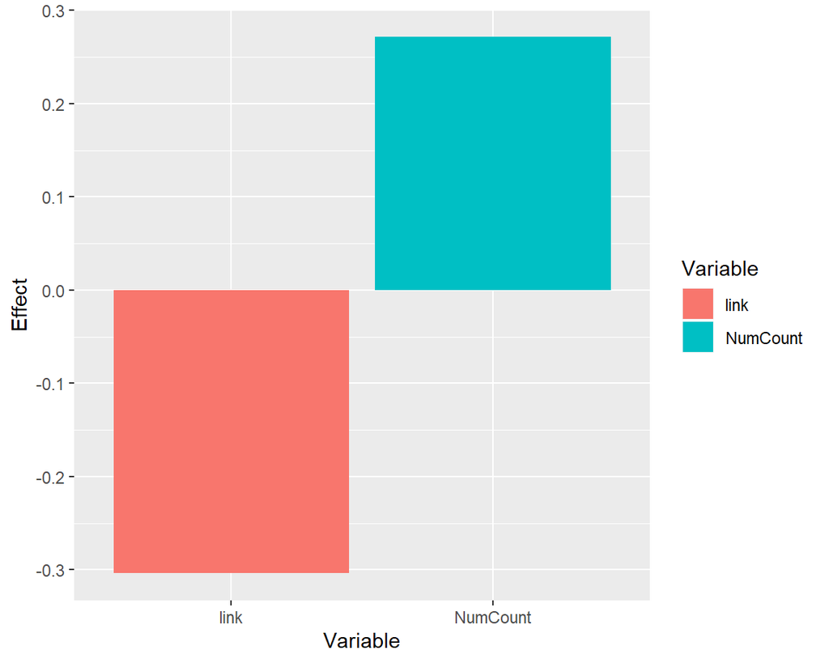